# Building Custom CPOs

### Data Format

Different `CPO` operations may want to operate on the data in different forms: as a `Task`, as a `data.frame` with or without the target column, etc. The `CPO` framework can perform some conversion of data to fit different needs, which is set up by the value of fthe **`dataformat`** parameter, together with **`dataformat.factor.with.ordered`**. While `dataformat` has slightly different effects on different `CPO` types, typically its values and effects are:

[output not shown]

Another parameter influencing the data format is the **`fix.factors`** flag which controls whether factor levels of prediction data need to be set to be the same as during training. If it is `TRUE`, previously unseen factor levels are set to `NA` during prediction.

### Properties

`mlr` and `mlrCPO` make it possible to specify what kind of data a `CPO` or a `Learner` can handle. However, since `CPO`s may change data to be more or less fitting for a certain `Learner`, a `CPO` must announce not only what data it can handle, but also how it changes the capabilities of the machine learning pipeline in which it is envolved. During construction, four parameters related to properties can be given.

The **`properties.data`** parameter defines what properties of feature data the `CPO` can handle; it must be a subset of `"numerics"`, `"factors"`, `"ordered"`, and `"missings"`. Typically, only the `"missings"` part is interesting since `CPO`s that only handle a subset of types will usually just ignore columns of other types.

The **`properties.target`** parameter defines what `Task` properties related to the task type and the target column a `CPO` can handle. It is a subset of `"cluster"`, `"classif"`, `"multilabel"`, `"regr"`, `"surv"` (so far defining the task type a `CPO` can handle), `"oneclass"`, `"twoclass"`, `"multiclass"` (properties specific to `classif` `Task`s). Most FOCPOs do not care about the task type, while TOCPOs may only support a single task type.

**`properties.adding`** lists the properties that a CPO *adds* to the capabilities of a machine learning pipeline when it is executed before it, while **`properties.needed`** lists the properties *needed* from the following pipeline. `cpoDummyEncode`, for example, a `CPO` that converts factors and ordereds to numerics, has `properties.adding == c("factors", "ordered")` and `properties.needed == "numerics"`. The many imputation `CPO`s have `properties.adding == "missings"`. Usually these are only a subset of the possible `properties.data` states, but for TOCPOs this may also be any of `"oneclass"`, `"twoclass"`, `"multiclass"`. Note that neither `properties.adding` nor `properties.needed` may be any task type, even for TOCPOs that perform task conversion.

#### Property Checking and `.sometimes` Properties

The `CPO` framework will check that a `CPO` only adds and removes the kind of data properties that it declared in `properties.adding` and `properties.needed`. It will also check that composition of `CPO`s, and attachment of `CPO`s to `Learner`s, work out. Sometimes, however, it is necessary to treat a `CPO` like it does a certain manipulation (removing `missings`, for example) in some cases, while not in others. A `CPO` that only imputes missings in *numeric* columns should be treated as `properties.adding == "missings"` when is is attached to a `Learner`, and the `Learner` should gain the `"missings"` property. However, when data that has missings in its factorial columns is given to this `CPO`, the `CPO` framework will complain that the `CPO` that declared `"missings"` in `properties.adding` returned data that still had missing values in it. The solution to this dilemma is to suffix some properties with “`.sometimes`” when declaring them in `properties.adding` and `properties.needed`. When composing `CPO`s, and when checking data *returned* by a `CPO`, the framework will then be as lenient as possible. In the given example, `properties.adding == "missings"` will be assumed when attaching the `CPO` to a `Learner`, while `properties.adding == character(0)` is assumed when checking the `CPO`’s output (and missing values that were not imputed are therefore forgiven).

### Packages

The single **`packages`** parameter can be set to a `character` vector listing packages necessary for a `CPO` to work. This is mostly useful when a `CPO` should be defined as part of a package or script to be distributed. The listed package will *not* automatically be *attached*, it will only be *loaded*. This means that a function exported by a package still needs to be called using `::`. The benefit of declaring it in `packages` is that it will be loaded upon *construction* of a `CPO`, which means that a user will get immediate feedback about whether the `CPO` can be used or needs more packages to be installed.

### Transformation Functions

The different types of `CPO`, and the different `make*()` functions, need different transformation functions to be defined. The principle behind these functions is alwasy the same, however: The `CPO` framework takes input data, transforms it according to `dataformat`, checks it according to `properties.data` and `properties.target`, and then gives it to one or more user-given transformation function. The transformation function must then usually create a control object containing information about the data to be used later, or transform the incoming data and return the transformation result (or both). The `CPO` framework then checks the transformed data according to `properties.adding` and `properties.needed` and gives it back to the `CPO` user.

Transformation functions are given to parameters starting with **`cpo.`**. They can either be given as functions, or as “**headless**” functions missing the `function(...)` part. In the latter case, the headless function must be a succession of expressions enclosed in curly braces (`{`, `}`) and the necessary function head is added by the `CPO` framework. The functions often take a subset of `data`, `target`, `control`, or `control.invert` parameters, in addition to all parameters as given in `par.set`.

#### Functional Transformation

The communication between transformation functions, e.g. giving the PCA matrix to its retrafo function, usually happens via “control” objects created by these functions and then given as parameter to other functions. In some cases, however, it may be more elegant to create a new function (e.g. a `cpo.retrafo` function) within another function as a “closure” (in the general, not R specific, sense) with access to all the outer functions variables. The `CPO` framework makes this possible by allowing a function to be given instead of a “control” object. The function which would usually receive this control object must then be given as `NULL` in the `makeCPO*()` call.

## Retrafoless CPOs

Retrafoless `CPO`s, or ROCPOs, are conceptually the simplest `CPO` type, since they do not create `CPOTrained` objects and therefore only need one transformation function: `cpo.trafo`. The value of the `dataformat` parameter may only be either `"df.all"` or `"task"`, resulting in either a `data.frame` (consisting all columns, including the target column) or a `Task` being given to the `cpo.trafo` function. `cpo.trafo` should have the parameters `data` (receiving the data as either a `Task` or `data.frame`), `target` (receiving the names of target columns in the data), and any parameter as given to `par.set`. The return value of `cpo.trafo` must be the transformed data, in the same format (`data.frame` or `Task`) as given as input.

Since a ROCPO only transforms incoming data during training, it should not do any transformation of target or feature values that would make it necessary to repeat this action during prediction. It may, for example, be used for subsampling a classification task to balance target classes, but it should not change the levels or values of given data rows.

The following is an example of a simplified version of the `cpoSample` `CPO`, which takes one parameter `fraction` and then subsamples a `fraction` part of incoming data without replacement:

```r
xmpSample = makeCPORetrafoless("exsample",  # nolint
  pSS(fraction: numeric[0, 1]),
  dataformat = "df.all",
  cpo.trafo = function(data, target, fraction) {
    newsize = round(nrow(data) * fraction)
    row.indices = sample(nrow(data), newsize)
    data[row.indices, ]
  })

cpo = xmpSample(0.01)
```

```r
iris %>>% cpo
```

```
#>    Sepal.Length Sepal.Width Petal.Length Petal.Width Species
#> 14          4.3         3.0          1.1         0.1  setosa
#> 50          5.0         3.3          1.4         0.2  setosa
```

It is possible to give the `cpo.trafo` as **headless** transformation function by just leaving out the function header. This can save a lot of boilerplate code when there are many parameters present, or when many transformation functions need to be given. The resulting `CPO` is completely equivalent to the one given above.

```r
xmpSampleHeadless = makeCPORetrafoless("exsample",  # nolint
  pSS(fraction: numeric[0, 1]),
  dataformat = "df.all",
  cpo.trafo = {
    newsize = round(nrow(data) * fraction)
    row.indices = sample(nrow(data), newsize)
    data[row.indices, ]
  })
```

## Feature Operation CPOs

FOCPOs are created with either the `makeCPO()` function, or the `makeCPOExtendedTrafo()` function. The former conceptually separates training from transformation, the latter separates transformation of training data from transformation of prediction data.

### `makeCPO()`

In principle, a FOCPO needs a function that “trains” a control object depending on the data (`cpo.train`), and another function that uses this control object, and new data, to perform the preprocessing operation (`cpo.retrafo`). The `cpo.train`-function must return a “control” object which contains all information about how to transform a given dataset. `cpo.retrafo` takes a (potentially new!) dataset *and* the “control” object returned by `cpo.trafo`, and transforms the new data according to plan.

In contrast to `makeCPORetrafoless()`, the `dataformat` parameter of `makeCPO()` can take all values described in the section Data Format. The `cpo.train` function takes the arguments `data`, `target`, and any other parameter described in `param.set`. The `data` value is the incoming data as a `Task`, a `data.frame` with or without the target column, or a list of `data.frames` of different column types, according to `dataformat`. The `target` value is a `character` vector of target names if `dataformat` is `"task"` or `"df.all"`, or a `data.frame` of the target columns otherwise.

The `cpo.train` function’s return value is treated as a `control` object and given to the `cpo.retrafo` function. Its parameters are `data`, `control`, and any parameters in `par.set`. The format of the data given to the `data` parameter is according to `dataformat`, with the exception that if `dataformat` is either `"task"` or `"df.all"`, it will be treated here as if its value were `"df.features"`. This is because the `cpo.retrafo` function is sometimes called with *prediction* data which does not have any target column at all.

It follows the simplified definition of a `CPO` that removes the numeric columns of smallest variance, returning a dataset of only `n.col` numeric columns. The `dataformat` variable is set to `"numeric"`, so that only numeric columns are given to the `CPO`’s transformation functiosn; factorial columns are ignored. In `cpo.trafo`, calculates the variance of each of the data’s columns, and in `cpo.retrafo` it subsets the data according to these variances. Since `cpo.retrafo` may also be called during prediction with new data, the variance must *not* be calculated in `cpo.retrafo`–this could lead to `cpo.retrafo` filtering out different columns from `cpo.trafo`. This example also prints out which of its functions are being called.

```r
xmpFilterVar = makeCPO("exemplvar",  # nolint
  pSS(n.col: integer[0, ]),
  dataformat = "numeric",
  cpo.train = function(data, target, n.col) {
    cat("*** cpo.train ***\n")
    sapply(data, var, na.rm = TRUE)
  },
  cpo.retrafo = function(data, control, n.col) {
    cat("*** cpo.retrafo ***\n")
    cat("Control:\n")
    print(control)
    cat("\n")
    greatest = order(-control)  # columns, ordered greatest to smallest var
    data[greatest[seq_len(n.col)]]
  })

cpo = xmpFilterVar(2)
```

(Note that the function heads are optional.)

When the `CPO` is called with a dataset, the `cpo.train` function is called first, creating the control object which is then given to `cpo.retrafo`.

```r
(trafd = head(iris) %>>% cpo)
```

```
#> *** cpo.train ***
#> *** cpo.retrafo ***
#> Control:
#> Sepal.Length  Sepal.Width Petal.Length  Petal.Width
#>  0.083000000  0.117666667  0.019000000  0.006666667
#>   Species Sepal.Width Sepal.Length
#> 1  setosa         3.5          5.1
#> 2  setosa         3.0          4.9
#> 3  setosa         3.2          4.7
#> 4  setosa         3.1          4.6
#> 5  setosa         3.6          5.0
#> 6  setosa         3.9          5.4
```

Note that the two columns of the entire `iris` dataset with the greatest variance are `Petal.Length` and `Sepal.Length`:

```r
head(iris %>>% cpo)
```

```
#> *** cpo.train ***
#> *** cpo.retrafo ***
#> Control:
#> Sepal.Length  Sepal.Width Petal.Length  Petal.Width
#>    0.6856935    0.1899794    3.1162779    0.5810063
#>   Species Petal.Length Sepal.Length
#> 1  setosa          1.4          5.1
#> 2  setosa          1.4          4.9
#> 3  setosa          1.3          4.7
#> 4  setosa          1.5          4.6
#> 5  setosa          1.4          5.0
#> 6  setosa          1.7          5.4
```

However, when applying the `retrafo()` of `trafd` to the entire dataset, the same columns are filtered out as they were in the first transformation: `Sepal.Width` and `Sepal.Length`. When the `retrafo()` is used, `cpo.train` is *not* called; instead, the `control` object saved inside the retrafo is used.

```r
head(iris %>>% retrafo(trafd))
```

```
#> *** cpo.retrafo ***
#> Control:
#> Sepal.Length  Sepal.Width Petal.Length  Petal.Width
#>  0.083000000  0.117666667  0.019000000  0.006666667
#>   Species Sepal.Width Sepal.Length
#> 1  setosa         3.5          5.1
#> 2  setosa         3.0          4.9
#> 3  setosa         3.2          4.7
#> 4  setosa         3.1          4.6
#> 5  setosa         3.6          5.0
#> 6  setosa         3.9          5.4
```

It is also possible to inspect the `CPOTrained` object to see that the `control` is there:

```r
getCPOTrainedState(retrafo(trafd))
```

```
#> $n.col
#> [1] 2
#>
#> $control
#> Sepal.Length  Sepal.Width Petal.Length  Petal.Width
#>  0.083000000  0.117666667  0.019000000  0.006666667
#>
#> $data
#> $data$shapeinfo.input
#> <ShapeInfo (input) Sepal.Length: num, Sepal.Width: num, Petal.Length: num, Petal.Width: num, Species: fac>
#>
#> $data$shapeinfo.output
#> <ShapeInfo (output)>:
#> numeric:
#> <ShapeInfo Sepal.Width: num, Sepal.Length: num>
#> factor:
#> <ShapeInfo Species: fac>
#> other:
#> <ShapeInfo (empty)>
```

#### Functional FOCPO

Instead of returning the `control` object, `cpo.train` may also return the `cpo.retrafo` *function*. This may be more succinct to write if there are many little pieces of information from the `cpo.train` run that the `cpo.retrafo` function should have access to.

When `cpo.retrafo` is given functionally, it should be a function with only *one* parameter: the newly incoming data. It can access the values of the `par.set` parameters from its encapsulating environment in `cpo.train`.

Note that the `data` and `target` values given to `cpo.train` are **deleted** after the `cpo.train` call, so `cpo.retrafo` does not have access to it. In fact, the `CPO` framework will give a warning about this.

```r
xmpFilterVarFunc = makeCPO("exemplvar.func",  # nolint
  pSS(n.col: integer[0, ]),
  dataformat = "numeric",
  cpo.retrafo = NULL,
  cpo.train = function(data, target, n.col) {
    cat("*** cpo.train ***\n")
    ctrl = sapply(data, var, na.rm = TRUE)
    function(x) {  # the data is given to the only present parameter: 'x'
      cat("*** cpo.retrafo ***\n")
      cat("Control:\n")
      print(ctrl)
      cat("\ndata:\n")
      print(data)  # 'data' is deleted: NULL
      cat("target:\n")
      print(target)  # 'target' is deleted: NULL
      greatest = order(-ctrl)  # columns, ordered greatest to smallest var
      x[greatest[seq_len(n.col)]]
    }
  })

cpo = xmpFilterVarFunc(2)
```

(Note that the function heads are optional.)

```r
(trafd = head(iris) %>>% cpo)
```

```
#> *** cpo.train ***
#> Warning in checkFunctionReturn(cpo.retrafo, "data", "cpo.retrafo", "cpo.train"): The function given as cpo.retrafo references a data and a target variable.
#> Beware that the 'data' and 'target' variable as given as an argument to the surrounding function
#> will not be accessible when cpo.retrafo is called.
#> If you still need to access this data, copy it to a variable with a different name.
#> If this warning is a false positive and you assign the 'data' variable properly, you can avoid
#> this warning by renaming the 'data' variable.
#> *** cpo.retrafo ***
#> Control:
#> Sepal.Length  Sepal.Width Petal.Length  Petal.Width
#>  0.083000000  0.117666667  0.019000000  0.006666667
#>
#> data:
#> NULL
#> target:
#> NULL
#>   Species Sepal.Width Sepal.Length
#> 1  setosa         3.5          5.1
#> 2  setosa         3.0          4.9
#> 3  setosa         3.2          4.7
#> 4  setosa         3.1          4.6
#> 5  setosa         3.6          5.0
#> 6  setosa         3.9          5.4
```

The `CPOTrained` state for a functional `CPO` is the *environment* of the retrafo function. It contains the “`ctrl`” variable defined during training, the parameters given to `cpo.train`, and the `cpo.retrafo` function itself. Note that `data` and `target` are deleted and replaced by different values.

```r
getCPOTrainedState(retrafo(trafd))
```

```
#> $ctrl
#> Sepal.Length  Sepal.Width Petal.Length  Petal.Width
#>  0.083000000  0.117666667  0.019000000  0.006666667
#>
#> $data
#> $data$shapeinfo.input
#> <ShapeInfo (input) Sepal.Length: num, Sepal.Width: num, Petal.Length: num, Petal.Width: num, Species: fac>
#>
#> $data$shapeinfo.output
#> <ShapeInfo (output)>:
#> numeric:
#> <ShapeInfo Sepal.Width: num, Sepal.Length: num>
#> factor:
#> <ShapeInfo Species: fac>
#> other:
#> <ShapeInfo (empty)>
#>
#>
#> $target
#> NULL
#>
#> $n.col
#> [1] 2
#>
#> $cpo.retrafo
#> function(x) {  # the data is given to the only present parameter: 'x'
#>       cat("*** cpo.retrafo ***\n")
#>       cat("Control:\n")
#>       print(ctrl)
#>       cat("\ndata:\n")
#>       print(data)  # 'data' is deleted: NULL
#>       cat("target:\n")
#>       print(target)  # 'target' is deleted: NULL
#>       greatest = order(-ctrl)  # columns, ordered greatest to smallest var
#>       x[greatest[seq_len(n.col)]]
#>     }
#> <environment: 0x14aa1908>
```

#### Stateless FOCPO

“Stateless” `CPO`s are `CPO`s that perform the same action during transformation of training and prediction data, independent from information during training. An example would be a `CPO` that converts all its columns to `numeric` columns. When a FOCPO does not need a state, the `cpo.train` parameter of `makeCPO()` can be set to `NULL`. The `cpo.retrafo` function then has no `control` paramter and instead only a `data` and any `par.set` parameter. The `as.numeric`-`CPO` could be written as the following:

```r
xmpAsNum = makeCPO("asnum",  # nolint
  cpo.train = NULL,
  cpo.retrafo = function(data) {
    data.frame(lapply(data, as.numeric))
  })

cpo = xmpAsNum()
```

(Note that the function head is optional.)

```r
(trafd = head(iris) %>>% cpo)
```

```
#>   Sepal.Length Sepal.Width Petal.Length Petal.Width Species
#> 1          5.1         3.5          1.4         0.2       1
#> 2          4.9         3.0          1.4         0.2       1
#> 3          4.7         3.2          1.3         0.2       1
#> 4          4.6         3.1          1.5         0.2       1
#> 5          5.0         3.6          1.4         0.2       1
#> 6          5.4         3.9          1.7         0.4       1
```

The “state” of the `CPOTrained` object thus created only contains information about the incoming *data shape*, to make sure that the `CPOTrained` object is only used on conforming data (as doing otherwise would indicate a bug).

```r
getCPOTrainedState(retrafo(trafd))
```

```
#> $data
#> $data$shapeinfo.input
#> <ShapeInfo (input) Sepal.Length: num, Sepal.Width: num, Petal.Length: num, Petal.Width: num, Species: fac>
#>
#> $data$shapeinfo.output
#> <ShapeInfo (output) Sepal.Length: num, Sepal.Width: num, Petal.Length: num, Petal.Width: num, Species: num>
```

### `makeCPOExtendedTrafo()`

Sometimes it is advantageous to have the training operation return the transformed data right away. PCA, for example, returns the rotation matrix *and* the transformed data; it would be a waste of time to only return the rotation matrix in a `cpo.train` function and apply it on the training data in `cpo.retrafo`. The `makeCPOExtendedTrafo()` function works very much like `makeCPO()`, with the difference that it has a `cpo.trafo` instead of a `cpo.train` function parameter. The `cpo.trafo` takes the same parameters as `cpo.train`, but returns the *transformed data* instead of a control object. The control object needs to be created *additionally*, as a variable by the `cpo.trafo` function. The `CPO` framework takes the value of a variable named `control` inside the `cpo.trafo` function and gives it to the `cpo.retrafo` function.

The following is a simplified version of the `cpoPca` `CPO`, which does not scale or center the data.

```r
xmpPca = makeCPOExtendedTrafo("simple.pca",  # nolint
  pSS(n.col: integer[0, ]),
  dataformat = "numeric",
  cpo.trafo = function(data, target, n.col) {
    cat("*** cpo.trafo ***\n")
    pcr = prcomp(as.matrix(data), center = FALSE, scale. = FALSE, rank = n.col)
    # save the rotation matrix as 'control' variable
    control = pcr$rotation
    pcr$x
  },
  cpo.retrafo = function(data, control, n.col) {
    cat("*** cpo.retrafo ***\n")
    # rotate the data by the rotation matrix
    as.matrix(data) %*% control
  })

cpo = xmpPca(2)
```

When this `CPO` is applied to data, only the `cpo.trafo` function is called.

```r
(trafd = head(iris) %>>% cpo)
```

```
#> *** cpo.trafo ***
#>   Species       PC1           PC2
#> 1  setosa -6.344251  3.699099e-05
#> 2  setosa -5.909522 -2.939100e-01
#> 3  setosa -5.835572 -1.780612e-02
#> 4  setosa -5.747518 -5.192580e-02
#> 5  setosa -6.319018  1.359890e-01
#> 6  setosa -6.882318  1.859359e-01
```

When the retrafo `CPOTrained` is used, the `cpo.retrafo` function is called, making use of the rotation matrix.

```r
tail(iris) %>>% retrafo(trafd)
```

```
#> *** cpo.retrafo ***
#>       Species       PC1        PC2
#> 145 virginica -8.614333 -0.7582980
#> 146 virginica -8.324575 -1.0203095
#> 147 virginica -7.667317 -1.2766319
#> 148 virginica -8.152840 -0.9708329
#> 149 virginica -8.190484 -0.4297855
#> 150 virginica -7.640937 -0.6764400
```

The rotation matrix can be inspected using `getCPOTrainedState`.

```r
getCPOTrainedState(retrafo(trafd))
```

```
#> $n.col
#> [1] 2
#>
#> $control
#>                     PC1         PC2
#> Sepal.Length -0.8012756 -0.55116118
#> Sepal.Width  -0.5489467  0.80835852
#> Petal.Length -0.2348418 -0.04199971
#> Petal.Width  -0.0382656  0.20251883
#>
#> $data
#> $data$shapeinfo.input
#> <ShapeInfo (input) Sepal.Length: num, Sepal.Width: num, Petal.Length: num, Petal.Width: num, Species: fac>
#>
#> $data$shapeinfo.output
#> <ShapeInfo (output)>:
#> numeric:
#> <ShapeInfo PC1: num, PC2: num>
#> factor:
#> <ShapeInfo Species: fac>
#> other:
#> <ShapeInfo (empty)>
```

#### Functional FOCPO

As with `makeCPO()`, `makeCPOExtendedTrafo()` makes it possible to define functional `CPO`s. Instead of *returning* a `cpo.retrafo` function, the `cpo.retrafo` function needs to be *defined* as a variable, instead of a “`control`” variable. Like in `makeCPO()`, the `cpo.retrafo` parameter of `makeCPOExtendedTrafo()` must then be `NULL`. The PCA example above could thus also be written as

```r
xmpPcaFunc = makeCPOExtendedTrafo("simple.pca.func",  # nolint
  pSS(n.col: integer[0, ]),
  dataformat = "numeric",
  cpo.retrafo = NULL,
  cpo.trafo = function(data, target, n.col) {
    cat("*** cpo.trafo ***\n")
    pcr = prcomp(as.matrix(data), center = FALSE, scale. = FALSE, rank = n.col)
    # save the rotation matrix as 'control' variable
    cpo.retrafo = function(data) {
      cat("*** cpo.retrafo ***\n")
      # rotate the data by the rotation matrix
      as.matrix(data) %*% pcr$rotation
    }
    pcr$x
  })

cpo = xmpPcaFunc(2)
```

```r
(trafd = head(iris) %>>% cpo)
```

```
#> *** cpo.trafo ***
#>   Species       PC1           PC2
#> 1  setosa -6.344251  3.699099e-05
#> 2  setosa -5.909522 -2.939100e-01
#> 3  setosa -5.835572 -1.780612e-02
#> 4  setosa -5.747518 -5.192580e-02
#> 5  setosa -6.319018  1.359890e-01
#> 6  setosa -6.882318  1.859359e-01
```

This also serves as an example of the disadvantages of a functional `CPO`: Since the `CPO` state contains all the information contained in the `cpo.trafo` call (except the `data` and `target` variables), it may take up more memory than needed. For this `CPO`, the state contains the `pcr` variable which contains the transformed training data in its `$x` slot. If the training data is a very large dataset, this would result in `CPO` states that take up a lot of working memory.

```r
getCPOTrainedState(retrafo(trafd))$pcr$x
```

```
#>         PC1           PC2
#> 1 -6.344251  3.699099e-05
#> 2 -5.909522 -2.939100e-01
#> 3 -5.835572 -1.780612e-02
#> 4 -5.747518 -5.192580e-02
#> 5 -6.319018  1.359890e-01
#> 6 -6.882318  1.859359e-01
```

## Target Operation CPOs

TOCPOs are more complicated than FOCPOs, since they potentially need to operate on data at three different points: During initial training, during the re-transformation for new prediction data, and during the inversion of predictions made by a model trained on transformed data. Similarly to `makeCPO()`, `makeCPOTargetOp()` splits these operations up into functions that create “`control`” objects, and functions that do the actual transformation. `makeCPOExtendedTargetOp()`, on the other hand, gives the user more flexibility at the price of the user having to make sure that transformation and retransformation perform the same operation–similarly to `makeCPOExtendedTrafo()` for FOCPOs.

### Task Type and Conversion

In contrast to FOCPOs, TOCPOs can only operate on one type of `Task`. Therefore, the `properties.target` parameter of `makeCPO*TargetOp()` must contain exactly one `Task` type (`"cluster"`, `"classif"`, `"regr"`, `"surv"`, `"multilabel"`) and possibly some more task properties (currently only `"oneclass"`, `"twoclass"`, `"multiclass"` if the `Task` type is `"classif"`).

It is possible to write TOCPOs that perform *conversion* of `Task` types. For that, the `task.type.out` parameter must be set to the `Task` type that the `CPO` converts the data to. If conversion happens, the transformation functions need to return target data fit for the `task.type.out` `Task` type.

`properties.adding` and `properties.needed` should *not* be any `Task` type, even when conversion happens. Only if one of the task types has *additional* properties–currently only the `"oneclass"`, `"twoclass"`, `"multiclass"` properties of classification `Task`s–should these additional properties be listed in `properties.adding` or `properties.needed`.

### `predict.type`

`mlr` makes it possible for `Learner`s to make different kinds of prediction. Usually they can predict a “response”, making their best effort to predict the true value of a task target. Many `Learner` types can predict a probability when their `predict.type` is set to `"prob"`, returning a `data.frame` of their estimated probability distribution over possible responses. For regression `Learner`s, `predict.type` can be `"se"` for the `Learner` to predict its estimated standard error of their response prediction.

When TOCPOs invert these predictions, they may

- declare which kind of `predict.type` predictions they can perform
- declare what `predict.type` they require from the underlying `Learner` to make this `predict.type` prediction.

This is done using the `predict.type.map` parameter of `makeCPO*TargetOp()`. It is a named `list` or named `character` vector with the names indicating the supported `predict.type`s, and the values indicating the required underlying predictions. For example, if a TOCPO can perform `"response"` and `"se"` prediction, and to predict `"response"` the underlying `Learner` must also perform `"response"` prediction, but for `"se"` prediction it must perform `"prob"` prediction, the `predict.type.map` would have the value

```r
c(response = "response", se = "prob")
```

### `makeCPOTargetOp()`

`makeCPOTargetOp()` has a `cpo.train` and `cpo.retrafo` function parameter that work similarly to the ones of `makeCPO()`. In contrast to `makeCPO()`, however, `cpo.retrafo` must return the *target* data instead of the feature data. The `data` and `target` parameters of `cpo.retrafo` get the same data as they get in a FOCPO created with `makeCPO()`, with the exception that if `dataformat` is `"task"` or `"df.all"`, the `target` parameter will receive the *whole* input data in form of a `Task` or `data.frame` (while the `data` argument, as in a FOCPO, will receive only the feature `data.frame`). The return value of `cpo.retrafo` for a TOCPO must always be in the same format as the input `target` value: a `data.frame` with the manipulated target values when `dataformat` is anything besides `"task"` or `"df.all"`, or a `Task` or `data.frame` of all data (with non-target columns unmodified) otherwise.

Inversion of predictions is performed using the functions `cpo.train.invert` and `cpo.invert`. `cpo.train.invert` takes a `data` and a `control` argument, and any arguments declared in the `par.set`. It is called whenever new data is fed into the `CPO` or its retrafo `CPOTrained`, and creates a `CPOTrained` state that is used to invert the prediction done on this new data. The `control` argument takes the value returned by the `cpo.train` function upon initial training, and the `data` argument is the new data for which to prepare the `CPOTrained` inverter. It has the form dictated by `dataformat`, with the exception that `"task"` and `"df.all"` `dataformat` are handled as `"df.feature"`; this is necessary since the new data could be a `data.frame` of data with unknown target.

The following is an example of a TOCPO that trains a classification `Learner` on a binary classification `Task` and changes it to a `Task` of whether or not the `Learner` predicted the truth for a given data line correctly. (Real-world applications would probably need to take some precautions against overfitting.) In its `cpo.train` step, the given `Learner` is trained on the incoming data and the resulting `WrappedModel` object is returned as the “`control`” object. This is given to the `cpo.retrafo` function, which performs prediction and creates a new classification `Task` with the match / mismatch between model prediction and ground truth as target. When an external `Learner` is trained on data that was preprocessed like this, its prediction will be whether the `CPO`-internal `Learner` can be trusted to predict a given data row. To “invert” this, i.e. to get the actual prediction, the `cpo.invert` function needs to have the internal `Learner`’s prediction as well as the prediction made by the external `Learner`. The former is provided by `cpo.train.invert`, which uses the `WrappedModel` to make a prediction on the new data, and given as `control.invert` to `cpo.invert`. The latter is the `target` data given to `cpo.invert`. This example `CPO` supports inverting both `"response"` and `"prob"` `predict.type` predictions, as declared in the `predict.type.map` argument. The actual `predict.type` to invert is given to `cpo.invert` as an argument.

```r
xmpMetaLearn = makeCPOTargetOp("xmp.meta",  # nolint
  pSS(lrn: untyped),
  dataformat = "task",
  properties.target = c("classif", "twoclass"),
  predict.type.map = c(response = "response", prob = "prob"),
  cpo.train = function(data, target, lrn) {
    cat("*** cpo.train ***\n")
    lrn = setPredictType(lrn, "prob")
    train(lrn, data)
  },
  cpo.retrafo = function(data, target, control, lrn) {
    cat("*** cpo.retrafo ***\n")
    prediction = predict(control, target)
    tname = getTaskTargetNames(target)
    tdata = getTaskData(target)
    tdata[[tname]] = factor(prediction$data$response == prediction$data$truth)
    makeClassifTask(getTaskId(target), tdata, tname, positive = "TRUE",
      fixup.data = "no", check.data = FALSE)
  },
  cpo.train.invert = function(data, control, lrn) {
    cat("*** cpo.train.invert ***\n")
    predict(control, newdata = data)$data
  },
  cpo.invert = function(target, control.invert, predict.type, lrn) {
    cat("*** cpo.invert ***\n")
    if (predict.type == "prob") {
      outmat = as.matrix(control.invert[grep("^prob\\.", names(control.invert))])
      revmat = outmat[, c(2, 1)]
      outmat * target[, "prob.TRUE", drop = TRUE] +
        revmat * target[, "prob.FALSE", drop = TRUE]
    } else {
      stopifnot(levels(target) == c("FALSE", "TRUE"))
      numeric.prediction = as.numeric(control.invert$response)
      numeric.res = ifelse(target == "TRUE",
        numeric.prediction,
        3 - numeric.prediction)
      factor(levels(control.invert$response)[numeric.res],
        levels(control.invert$response))
    }
  })

cpo = xmpMetaLearn(makeLearner("classif.logreg"))
```

To show the inner workings of this `CPO`, the following example data is used.

```r
set.seed(12)
split = makeResampleInstance(hout, pid.task)
train.task = subsetTask(pid.task, split$train.inds[[1]])
test.task = subsetTask(pid.task, split$predict.inds[[1]])
```

It can be instructive to watch the `cat()` output of this `CPO` to see which function gets called at what point in the lifecycle. The `cpo.train` function is called first to create the `control` object. The `Task` is transformed in `cpo.retrafo`. Also `cpo.train.invert` is called, since an `inverter` attribute is attached to the returned trafo.

```r
trafd = train.task %>>% cpo
```

```
#> *** cpo.train ***
#> *** cpo.train.invert ***
#> *** cpo.retrafo ***
```

```r
attributes(trafd)
```

```
#> $names
#> [1] "type"        "env"         "weights"     "blocking"    "coordinates"
#> [6] "task.desc"
#>
#> $class
#> [1] "ClassifTask"    "SupervisedTask" "Task"
#>
#> $retrafo
#> CPO Retrafo chain {type:classif}
#> [RETRAFO xmp.meta(lrn = <classif.log...)]
#>
#> $inverter
#> CPO Inverter chain {type:classif} (able to predict 'response', 'prob')
#> [INVERTER xmp.meta(lrn = <classif.log...){type:classif}]
```

The values of the target column (“diabetes”) of the result can be compared with the prediction of a `"classif.logreg"` `Learner` on the same data:

```r
head(getTaskData(trafd))
```

```
#>     pregnant glucose pressure triceps insulin mass pedigree age diabetes
#> 450        0     120       74      18      63 30.5    0.285  26     TRUE
#> 346        8     126       88      36     108 38.5    0.349  49    FALSE
#> 336        0     165       76      43     255 47.9    0.259  26    FALSE
#> 247       10     122       68       0       0 31.2    0.258  41     TRUE
#> 174        1      79       60      42      48 43.5    0.678  23     TRUE
#> 453        0      91       68      32     210 39.9    0.381  25     TRUE
```

```r
model = train(makeLearner("classif.logreg", predict.type = "prob"), train.task)
head(predict(model, train.task)$data[c("truth", "response")])
```

```
#>     truth response
#> 450   neg      neg
#> 346   neg      pos
#> 336   neg      pos
#> 247   neg      neg
#> 174   neg      neg
#> 453   neg      neg
```

When new data is transformed using the retrafo `CPOTrained`, another `inverter` attribute is created, and hence `cpo.train.invert` is called again. Since the target column of the `test.task` in the following example is also transformed, the `cpo.retrafo` function is called.

```r
retr = test.task %>>% retrafo(trafd)
```

```
#> *** cpo.retrafo ***
#> *** cpo.train.invert ***
```

```r
attributes(retr)
```

```
#> $names
#> [1] "type"        "env"         "weights"     "blocking"    "coordinates"
#> [6] "task.desc"
#>
#> $class
#> [1] "ClassifTask"    "SupervisedTask" "Task"
#>
#> $inverter
#> CPO Inverter chain {type:classif} (able to predict 'response', 'prob')
#> [INVERTER xmp.meta(lrn = <classif.log...){type:classif}]
```

```r
retr.df = getTaskData(test.task, target.extra = TRUE)$data %>>% retrafo(trafd)
```

```
#> *** cpo.train.invert ***
```

```r
names(attributes(retr.df))
```

```
#> [1] "names"     "class"     "row.names" "inverter"
```

The invert functionality can be demonstrated by making a prediction with an external model.

```r
ext.model = train("classif.svm", trafd)
ext.pred = predict(ext.model, retr)
newpred = invert(inverter(retr), ext.pred)
```

```
#> *** cpo.invert ***
```

```r
performance(newpred)
```

```
#>      mmce
#> 0.2200521
```

It may also be instructive to attach the `xmpMetaLearn` `CPO` to a `Learner` to see which functions get called during training and prediction of a TOCPO-`Learner`. Since the `Learner` does not do inversion of the training data, a `CPOTrained` for inversion is not created during training, and `cpo.train.invert` is hence not called. Only `cpo.train` (for control object creation) and `cpo.retrafo` (target value change) are called. During prediction, the input data is used to create an (internally used) inversion `CPOTrained` which promptly gets used by the prediction made by `"classif.svm"`. Hence both `cpo.train.invert` and `cpo.invert` are called in succession.

```r
cpo.learner = cpo %>>% makeLearner("classif.svm")
cpo.model = train(cpo.learner, train.task)
```

```
#> *** cpo.train ***
#> *** cpo.retrafo ***
```

```r
lrnpred = predict(cpo.model, test.task)
```

```
#> *** cpo.train.invert ***
#> *** cpo.invert ***
```

```r
performance(lrnpred)
```

```
#>      mmce
#> 0.2200521
```

See Postscriptum for an evaluation of `xmpMeatLearn`’s performance.

#### Functional TOCPO

Just like for FOCPOs, it is possible to create functional TOCPOs. In the case of `makeCPOTargetOp()`, it is possible to have `cpo.train` create `cpo.retrafo` and `cpo.train.invert`, instead of giving them to `makeCPOTargetOp()` directly. Just as in `makeCPO`, these functions can then access the state of their environment in the `cpo.train` call and hence have neither a `control` argument, nor any arguments for the `par.set` parameters. Since `cpo.train` must in this case create two functions, these functions only need to be defined within `cpo.train`, the return value is ignored.

Note that `cpo.retrafo` and `cpo.train.invert` must either be both functional or both object based.

It is furthermore possible to return a `cpo.invert` function by `cpo.train.invert`, instead of giving it to `makeCPOTargetOp()`. As above, the returned function should not have any parameters for the ones given in `par.set`, and should not have a `control.invert`. `cpo.invert` can be functional or not, *independently* of whether `cpo.retrafo` and `cpo.train.invert` are functional.

As in `makeCPO()`, all functions that are given functionally must be explicitly set to `NULL` in the `makeCPOTargetOp()` call.

The `xmpMetaLearn` example above with functional `cpo.retrafo`, `cpo.train.invert` and `cpo.invert` would look like the following:

```r
xmpMetaLearn = makeCPOTargetOp("xmp.meta.fnc",  # nolint
  pSS(lrn: untyped),
  dataformat = "task",
  properties.target = c("classif", "twoclass"),
  predict.type.map = c(response = "response", prob = "prob"),
  # set the cpo.* parameters not needed to NULL:
  cpo.retrafo = NULL, cpo.train.invert = NULL, cpo.invert = NULL,
  cpo.train = function(data, target, lrn) {
    cat("*** cpo.train ***\n")
    lrn = setPredictType(lrn, "prob")
    model = train(lrn, data)
    cpo.retrafo = function(data, target) {
      cat("*** cpo.retrafo ***\n")
      prediction = predict(model, target)
      tname = getTaskTargetNames(target)
      tdata = getTaskData(target)
      tdata[[tname]] = factor(prediction$data$response == prediction$data$truth)
      makeClassifTask(getTaskId(target), tdata, tname, positive = "TRUE",
        fixup.data = "no", check.data = FALSE)
    }
    cpo.train.invert = function(data) {
      cat("*** cpo.train.invert ***\n")
      prediction = predict(model, newdata = data)$data
      function(target, predict.type) {  # this is returned as cpo.invert
        cat("*** cpo.invert ***\n")
        if (predict.type == "prob") {
          outmat = as.matrix(prediction[grep("^prob\\.", names(prediction))])
          revmat = outmat[, c(2, 1)]
          outmat * target[, "prob.TRUE", drop = TRUE] +
            revmat * target[, "prob.FALSE", drop = TRUE]
        } else {
          stopifnot(levels(target) == c("FALSE", "TRUE"))
          numeric.prediction = as.numeric(prediction$response)
          numeric.res = ifelse(target == "TRUE",
            numeric.prediction,
            3 - numeric.prediction)
          factor(levels(prediction$response)[numeric.res],
            levels(prediction$response))
        }
      }
    }
  })
```

#### Constant Invert TOCPOs

The following example is a TOCPO for regression `Task`s that centers target values during training. After prediction, the data is inverted by adding the original mean of the training data to the predictions. This inversion operation does not need any information about the prediction data going in, so the TOCPO can be declared `constant.invert`.

The `cpo.retrafo` function is also called when new prediction data *with* a target column is transformed (as during model validation). In that case, the mean of the *training data* column is subtracted. Therefore the mean generated by `cpo.train` needs to be used in `cpo.retrafo` (i.e. the `control` value), not the mean of the `target` data present.

```r
xmpRegCenter = makeCPOTargetOp("xmp.center",  # nolint
  constant.invert = TRUE,
  cpo.train.invert = NULL,  # necessary for constant.invert = TRUE
  dataformat = "df.feature",
  properties.target = "regr",
  cpo.train = function(data, target) {
    # control value is just the mean of the target column
    mean(target[[1]])
  },
  cpo.retrafo = function(data, target, control) {
    # subtract mean from target column in retrafo
    target[[1]] = target[[1]] - control
    target
  },
  cpo.invert = function(target, predict.type, control.invert) {
    target + control.invert
  })

cpo = xmpRegCenter()
```

To illustrate this `CPO`, the following data is used:

```r
train.task = subsetTask(bh.task, 150:155)
getTaskTargets(train.task)
```

```
#> [1] 15.4 21.5 19.6 15.3 19.4 17.0
```

```r
predict.task = subsetTask(bh.task, 156:160)
getTaskTargets(predict.task)
```

```
#> [1] 15.6 13.1 41.3 24.3 23.3
```

The target column of the task after transformation has a mean of 0.

```r
trafd = train.task %>>% cpo
getTaskTargets(trafd)
```

```
#> [1] -2.633333  3.466667  1.566667 -2.733333  1.366667 -1.033333
```

When applying the retrafo `CPOTrained` to a new task, the mean of the training task target column is subtracted.

```r
getTaskTargets(predict.task)
```

```
#> [1] 15.6 13.1 41.3 24.3 23.3
```

```r
retr = retrafo(trafd)
predict.traf = predict.task %>>% retr
getTaskTargets(predict.traf)
```

```
#> [1] -2.433333 -4.933333 23.266667  6.266667  5.266667
```

When inverting a regression prediction, the mean of the training data target column is added to the prediction.

```r
model = train("regr.lm", trafd)
pred = predict(model, predict.traf)
pred
```

```
#> Prediction: 5 observations
#> predict.type: response
#> threshold:
#> time: 0.00
#>     id     truth  response
#> 156  1 -2.433333 -2.854142
#> 157  2 -4.933333  5.802064
#> 158  3 23.266667 14.442103
#> 159  4  6.266667  8.302782
#> 160  5  5.266667  8.633308
```

```r
invert(inverter(predict.traf), pred)
```

```
#> Prediction: 5 observations
#> predict.type: response
#> threshold:
#> time: 0.00
#>     id truth response
#> 156  1  15.6 15.17919
#> 157  2  13.1 23.83540
#> 158  3  41.3 32.47544
#> 159  4  24.3 26.33611
#> 160  5  23.3 26.66664
```

Since `"regr.lm"` is translation invariant and deterministic, the prediction equals the prediction made without centering the target:

```r
model = train("regr.lm", train.task)
predict(model, predict.task)
```

[output not shown]

A special property of `constant.invert` TOCPOs is that their retrafo `CPOTrained` can also be used for inversion. This is the case since the tight coupling of inversion operation to the data used to create the prediction is not necessary when the inversion is actually independent of this data. This is indicated by `getCPOTrainedCapability()` returning a vector with the `"invert"` capability set to `1`. However, when using the retrafo `CPOTrained` for inversion, the “truth” column is absent from the inverted prediction.

```r
getCPOTrainedCapability(retr)
```

```
#> retrafo  invert
#>       1       1
```

```r
invert(retr, pred)
```

```
#> Prediction: 5 observations
#> predict.type: response
#> threshold:
#> time: 0.00
#>     id response
#> 156  1 15.17919
#> 157  2 23.83540
#> 158  3 32.47544
#> 159  4 26.33611
#> 160  5 26.66664
```

#### Functional Constant Invert TOCPO

Just as above, `constant.invert` TOCPOs can be *functional*. For this, the `cpo.train` function must declare both a `cpo.retrafo` *and* a `cpo.invert` variable which perform the requested operations. These functions have no `control` or `control.invert` parameter, and no parameters pertaining to `par.set`.

#### Stateless TOCPO

Very simple target column operations that operate on a row-by-row basis without needing information e.g. from training data, can be declared as “stateless”. Similarly to `makeCPO()`, when `cpo.train` parameter is set to `NULL`, no control object is created for a `CPOTrained`. Furthermore, a stateless TOCPO must always have `constant.invert` set as well. Therefore, only `cpo.retrafo` and `cpo.invert` are given as functions, both without a `control` or `control.invert` argument. One example is a TOCPO that log-transforms the target column of a regression task, and exponentiates the predictions made from this during inversion. (A better inversion would take the `"se"` prediction into account, see `cpoLogTrafoRegr`.)

```r
xmpLogRegr = makeCPOTargetOp("log.regr",  # nolint
  constant.invert = TRUE,
  properties.target = "regr",
  cpo.train = NULL, cpo.train.invert = NULL,
  cpo.retrafo = function(data, target) {
    target[[1]] = log(target[[1]])
    target
  },
  cpo.invert = function(target, predict.type) {
    exp(target)
  })

cpo = xmpLogRegr()
```

The `CPO` takes the logarithm of the task target column both during training and when using the retrafo `CPOTrained`.

```r
trafd = train.task %>>% cpo
getTaskTargets(trafd)
```

```
#> [1] 2.734368 3.068053 2.975530 2.727853 2.965273 2.833213
```

```r
retr = retrafo(trafd)
predict.traf = predict.task %>>% retr
getTaskTargets(predict.traf)
```

```
#> [1] 2.747271 2.572612 3.720862 3.190476 3.148453
```

```r
model = train("regr.lm", trafd)
pred = predict(model, predict.traf)
pred
```

```
#> Prediction: 5 observations
#> predict.type: response
#> threshold:
#> time: 0.00
#>     id    truth response
#> 156  1 2.747271 2.726065
#> 157  2 2.572612 3.224557
#> 158  3 3.720862 3.685047
#> 159  4 3.190476 3.353014
#> 160  5 3.148453 3.365374
```

Note that both the inverter *and* the retrafo `CPOTrained` can be used for inversion, since a stateless TOCPO also has `constant.invert` set. As above, when using the retrafo `CPOTrained`, the truth column is absent from the result.

```r
invert(inverter(predict.traf), pred)
```

```
#> Prediction: 5 observations
#> predict.type: response
#> threshold:
#> time: 0.00
#>     id truth response
#> 156  1  15.6 15.27267
#> 157  2  13.1 25.14244
#> 158  3  41.3 39.84699
#> 159  4  24.3 28.58876
#> 160  5  23.3 28.94433
```

```r
invert(retr, pred)
```

```
#> Prediction: 5 observations
#> predict.type: response
#> threshold:
#> time: 0.00
#>     id response
#> 156  1 15.27267
#> 157  2 25.14244
#> 158  3 39.84699
#> 159  4 28.58876
#> 160  5 28.94433
```

### `makeCPOExtendedTargetOp()`

Just as for FOCPOs, it is possible to declare a TOCPO while having more direct control over what happens at which stage of training, re-transformation, or inversion. In a TOCPO defined with `makeCPOTargetOp()`, the `cpo.retrafo` and `cpo.train.invert` functions are called automatically when necessary during training and re-transformation. `makeCPOExtendedTargetOp()` instead has a `cpo.trafo` and a `cpo.retrafo` parameter, which get called during the respective operation.

`cpo.trafo` must be a function taking the same parameters as `cpo.train` in `makeCPOTargetOp()`. Instead of returning a control object, it must define a variable named “`control`”, and a variable named “`control.invert`”. The former is used as the `control` argument of `cpo.retrafo`, the latter is used as `control.invert` for `cpo.invert` when using the inverter `CPOTrained` created during training. The return value of `cpo.trafo` must be similar to the value returned by `cpo.retrafo` in `makeCPOTargetOp()`: it must be the modified data set or target, depending on `dataformat`.

`cpo.invert` works just as in `makeCPOTargetOp()`.

The following is a nonsensical, synthetic example that adds `1` to the target column of a regression `Task` during initial training, subtracts `1` during retrafo re-application and is a no-op during inversion.

```r
xmpSynCPO = makeCPOExtendedTargetOp("syn.cpo",  # nolint
  properties.target = "regr",
  cpo.trafo = function(data, target) {
    cat("*** cpo.trafo ***\n")
    target[[1]] = target[[1]] + 1
    control = "control created in cpo.trafo"
    control.invert = "control.invert created in cpo.trafo"
    target
  },
  cpo.retrafo = function(data, target, control) {
    cat("*** cpo.retrafo ***", "control is:", deparse(control), sep = "\n")
    control.invert = "control.invert created in cpo.retrafo"
    if (!is.null(target)) {
      cat("target is non-NULL, performing transformation\n")
      target[[1]] = target[[1]] - 1
      return(target)
    } else {
      cat("target is NULL, no transformation (but control.invert was created)\n")
      return(NULL)  # is ignored.
    }
  },
  cpo.invert = function(target, control.invert, predict.type) {
    cat("*** invert ***", "control.invert is:", deparse(control.invert),
      sep = "\n")
    target
  })

cpo = xmpSynCPO()
```

For an “extended” TOCPO, only one of the transformation functions is called in each invocation. Initial transformation calls `cpo.trafo` and adds `1` to the targets; using the `CPOTrained` for re-transformation calls `cpo.retrafo` and subtracts `1`.

```r
trafd = train.task %>>% cpo
```

```
#> *** cpo.trafo ***
```

```r
getTaskTargets(trafd)
```

```
#> [1] 16.4 22.5 20.6 16.3 20.4 18.0
```

```r
retrafd = train.task %>>% retrafo(trafd)
```

```
#> *** cpo.retrafo ***
#> control is:
#> "control created in cpo.trafo"
#> target is non-NULL, performing transformation
```

```r
getTaskTargets(retrafd)
```

```
#> [1] 14.4 20.5 18.6 14.3 18.4 16.0
```

It is also possible to perform re-transformation with a `data.frame` that does not include the target column. In that case the `target` value given to `cpo.retrafo` will be `NULL`, as reported by that function in this example:

```r
retrafd = getTaskData(train.task, target.extra = TRUE)$data %>>% retrafo(trafd)
```

```
#> *** cpo.retrafo ***
#> control is:
#> "control created in cpo.trafo"
#> target is NULL, no transformation (but control.invert was created)
```

The `trafd` object has an inverter `CPOTrained` attribute that was created by `cpo.trafo`, the `retrafd` object has an inverter `CPOTrained` attribute created by `cpo.retrafo` (necessarily). This is made visible by the given example inverter function:

```r
inv = invert(inverter(trafd), 1:6)
```

```
#> *** invert ***
#> control.invert is:
#> "control.invert created in cpo.trafo"
```

```r
inv = invert(inverter(retrafd), 1:6)
```

```
#> *** invert ***
#> control.invert is:
#> "control.invert created in cpo.retrafo"
```

## Postscriptum

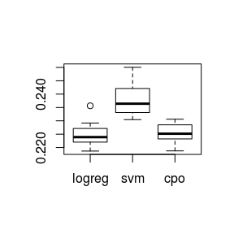

```r
learners = list(
    logreg = makeLearner("classif.logreg"),
    svm = makeLearner("classif.svm"),
    cpo = xmpMetaLearn(makeLearner("classif.logreg")) %>>%
      makeLearner("classif.svm")
)

# suppress output of '*** cpo.train ***' etc.
configureMlr(show.info = FALSE, show.learner.output = FALSE)

perfs = sapply(learners, function(lrn) {
  unname(replicate(20, resample(lrn, pid.task, cv10)$aggr))
})

# reset mlr settings
configureMlr()

boxplot(perfs)
```

P-Values of comparing the `CPOLearner` to both `"classif.logreg"`, and `"classif.svm"`:

```r
pvals = c(
    logreg = t.test(perfs[, "logreg"], perfs[, "cpo"], "greater")$p.value,
    svm = t.test(perfs[, "svm"], perfs[, "cpo"], "greater")$p.value
)

round(p.adjust(pvals), 3)
```

```
#> logreg    svm
#>  0.732  0.000
```